# Tutorial

Chunlei Zheng

2019-02-27

```r
library(earthquake)
library(ggplot2)
library(tidyr)
library(dplyr)
```

## Introduction

The overall goal of the R package is to work with this dataset and provide the tools for processing and visualizing the data so that others may extract some use out of the information embedded within.

## Timeline visualization

Given countries, we can use geom_timeline to visualize three types of information: the times at which earthquakes occur within certain countries, the magnitudes (i.e. Richter scale value) and the number of deaths associated with each earthquake. For example,

1. Cleaned data has been included in this package, first let look at these data

```r
# fname <- system.file("extdata", "signif.txt.tsv", package="earthquake")
# eq_dat_raw <- as.data.frame(readr::read_tsv(fname))
# eq_dat_clean <- earthquake::eq_clean_data(eq_dat_raw)
str(earthquake::eq_dat_clean)
```

```
#> 'data.frame':    5954 obs. of  48 variables:
#>  $ I_D                               : int  1 2 3 5877 8 11 9712 12 13 14 ...
#>  $ FLAG_TSUNAMI                      : chr  NA "Tsu" NA "Tsu" ...
#>  $ YEAR                              : int  -2150 -2000 -2000 -1610 -1566 -1450 -1365 -1250 -1050 -759 ...
#>  $ MONTH                             : int  NA NA NA NA NA NA NA NA NA NA ...
#>  $ DAY                               : int  NA NA NA NA NA NA NA NA NA NA ...
#>  $ HOUR                              : int  NA NA NA NA NA NA NA NA NA NA ...
#>  $ MINUTE                            : int  NA NA NA NA NA NA NA NA NA NA ...
#>  $ SECOND                            : chr  NA NA NA NA ...
#>  $ FOCAL_DEPTH                       : int  NA NA 18 NA NA NA NA NA NA NA ...
#>  $ EQ_PRIMARY                        : num  7.3 NA 7.1 NA NA NA NA 6.5 6.2 NA ...
#>  $ EQ_MAG_MW                         : num  NA NA NA NA NA NA NA NA NA NA ...
#>  $ EQ_MAG_MS                         : num  NA NA 7.1 NA NA NA NA NA NA NA ...
#>  $ EQ_MAG_MB                         : chr  NA NA NA NA ...
#>  $ EQ_MAG_ML                         : num  NA NA NA NA NA NA NA NA NA NA ...
#>  $ EQ_MAG_MFA                        : chr  NA NA NA NA ...
#>  $ EQ_MAG_UNK                        : num  7.3 NA NA NA NA NA NA 6.5 6.2 NA ...
#>  $ INTENSITY                         : int  NA 10 10 NA 10 10 NA NA NA 11 ...
#>  $ COUNTRY                           : chr  "JORDAN" "SYRIA" "TURKMENISTAN" "GREECE" ...
#>  $ STATE                             : chr  NA NA NA NA ...
#>  $ LOCATION_NAME                     : chr  "Bab-a-Daraa,Al-Karak" "Ugarit" "w" "Thera Island (Santorini)" ...
#>  $ LATITUDE                          : num  31.1 35.7 38 36.4 31.5 ...
#>  $ LONGITUDE                         : num  35.5 35.8 58.2 25.4 35.3 25.5 35.8 35.5 35 35.5 ...
#>  $ REGION_CODE                       : int  140 130 40 130 140 130 140 140 140 140 ...
#>  $ DEATHS                            : int  NA NA 1 NA NA NA NA NA NA NA ...
#>  $ DEATHS_DESCRIPTION                : int  NA 3 1 NA NA NA NA NA NA NA ...
#>  $ MISSING                           : chr  NA NA NA NA ...
#>  $ MISSING_DESCRIPTION               : int  NA NA NA NA NA NA NA NA NA NA ...
#>  $ INJURIES                          : int  NA NA NA NA NA NA NA NA NA NA ...
#>  $ INJURIES_DESCRIPTION              : int  NA NA NA NA NA NA NA NA NA NA ...
#>  $ DAMAGE_MILLIONS_DOLLARS           : chr  NA NA NA NA ...
#>  $ DAMAGE_DESCRIPTION                : int  3 NA 1 NA 3 NA 3 3 3 3 ...
#>  $ HOUSES_DESTROYED                  : int  NA NA NA NA NA NA NA NA NA NA ...
#>  $ HOUSES_DESTROYED_DESCRIPTION      : int  NA NA 1 NA NA NA NA NA NA NA ...
#>  $ HOUSES_DAMAGED                    : int  NA NA NA NA NA NA NA NA NA NA ...
#>  $ HOUSES_DAMAGED_DESCRIPTION        : int  NA NA NA NA NA NA NA NA NA NA ...
#>  $ TOTAL_DEATHS                      : int  NA NA 1 NA NA NA NA NA NA NA ...
#>  $ TOTAL_DEATHS_DESCRIPTION          : int  NA 3 1 3 NA NA NA NA NA NA ...
#>  $ TOTAL_MISSING                     : chr  NA NA NA NA ...
#>  $ TOTAL_MISSING_DESCRIPTION         : chr  NA NA NA NA ...
```

[output cut: 93 more lines]

[output not shown]

2. Choose the countries you want to look at

```r
dat <- dplyr::select(eq_dat_clean, DATE, COUNTRY, LOCATION_NAME, LONGITUDE, LATITUDE,
               EQ_MAG_MS, EQ_PRIMARY, TOTAL_DEATHS) %>%
  filter(COUNTRY %in% c("USA", "CHINA"))
```

3. Give time span parameters and draw a timeline

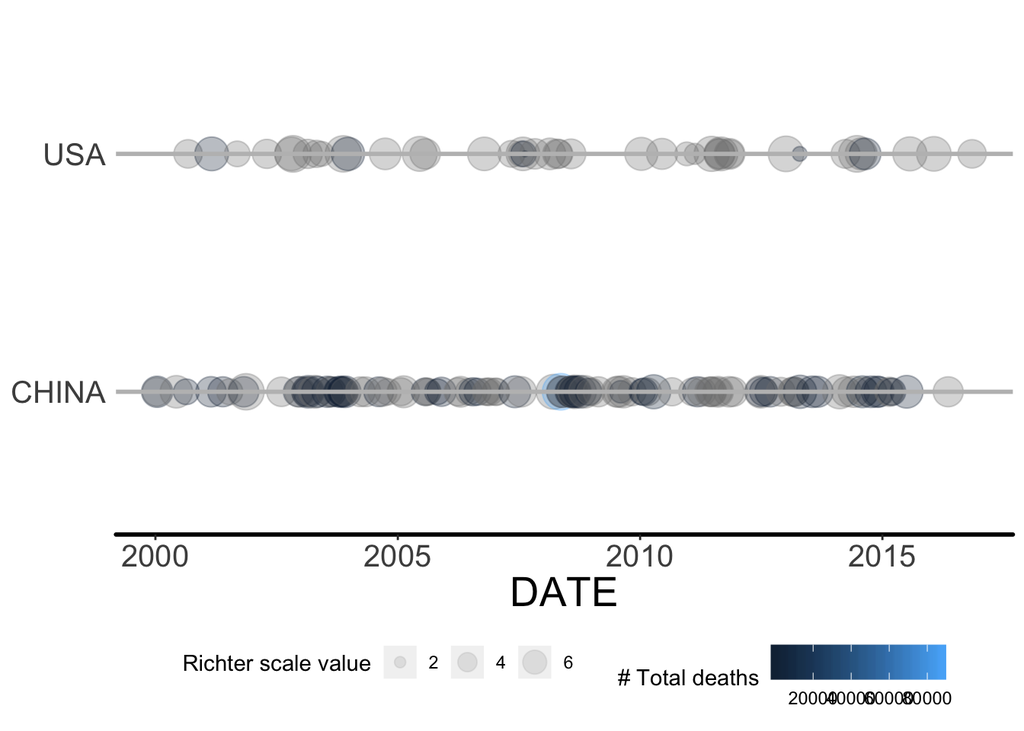

```r
tl <- ggplot2::ggplot(data = dat, aes(x=DATE,
                              size=as.numeric(EQ_PRIMARY),
                              fill=as.numeric(TOTAL_DEATHS),
                              y=COUNTRY)) +
  geom_timeline(xmin=as.Date("2000-01-01"), xmax=as.Date("2017-01-01"), stat="Timeline") +
  scale_fill_gradient(name="# Total deaths") +
  scale_size_continuous(name="Richter scale value") +
  theme_timeline

tl
```

If you want to know more specific locations for big earthquakes, geom_timeline_label can add this information. For example,

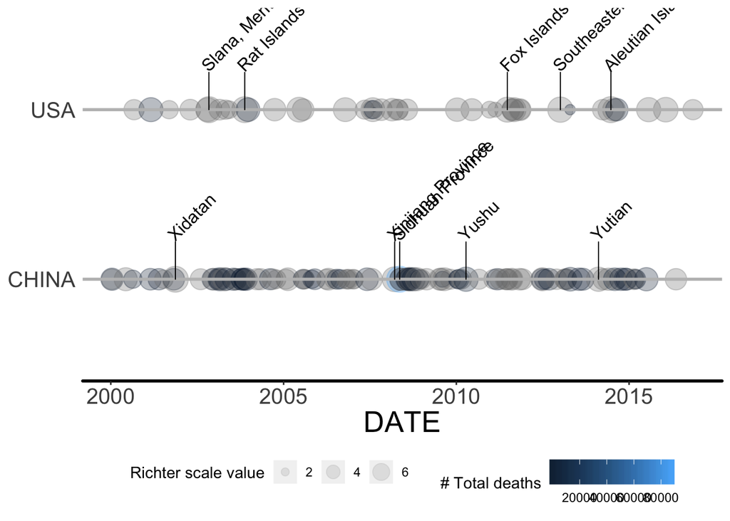

```r
tl <- ggplot2::ggplot(data = dat, aes(x=DATE,
                              size=as.numeric(EQ_PRIMARY),
                              fill=as.numeric(TOTAL_DEATHS),
                              y=COUNTRY)) +
  geom_timeline(xmin=as.Date("2000-01-01"), xmax=as.Date("2017-01-01"), stat="Timeline") +
  geom_timeline_label(aes(label = LOCATION_NAME),n_max=5, xmin=as.Date("2000-01-01"), xmax=as.Date("2017-01-01")) +
  scale_fill_gradient(name="# Total deaths") +
  scale_size_continuous(name="Richter scale value") +
  theme_timeline

tl
```

## Interactive map visualization

In addition to building tools to visualize the earthquakes in time, it’s important that we can visualize them in space too. In this module we will build some tools for mapping the earthquake epicenters and providing some annotations with the mapped data.

eq_map() function takes an argument data containing the filtered data frame with earthquakes to visualize. The function maps the epicenters (LATITUDE/LONGITUDE) and annotates each point with in pop up window containing annotation data stored in a column of the data frame. We can choose which column is used for the annotation in the pop-up with a function argument named annot_col. Each earthquake was shown with a circle, and the radius of the circle is proportional to the earthquake’s magnitude (EQ_PRIMARY). For example,

```r
eq_dat_clean %>%
  dplyr::filter(COUNTRY == "MEXICO" & lubridate::year(DATE) >= 2000) %>%
  eq_map(annot_col = "DATE")
```

[interactive chart not shown]

In addition,it would be useful to have more interesting pop-ups for the interactive map created with the eq_map() function. eq_create_label() that takes the dataset as an argument and creates an HTML label that provides three types of information for each earquake, including the location, the magnitude (EQ_PRIMARY), and the total number of deaths (TOTAL_DEATHS). For example,

```r
eq_dat_clean %>%
  dplyr::filter(COUNTRY == "CHINA" & lubridate::year(DATE) >= 2000) %>%
  dplyr::mutate(popup_text = eq_create_label(.)) %>%
  eq_map(annot_col = "popup_text")
```

[interactive chart not shown]